# Affect-AAT model

Kristina Kobrock

14 3 2022

# The role of affect in the Automatic Approach Bias: An empirical investigation.

## The effect of mood induction in the AAB

Load the preprocessed data (see DataAnalysis.Rmd for details).

```r
load("affect-aat.Rdata")
```

### Hypotheses from the preregistration:

1. Negative mood facilitates performance in the incongruent condition (i.e., avoiding positive stimuli and approaching negative stimuli) - possibly counterbalancing the AAB.
2. Positive mood facilitates performance in the congruent condition (i.e., approaching positive stimuli and avoiding negative stimuli).

### Visual inspection:

Visual inspection of the data:

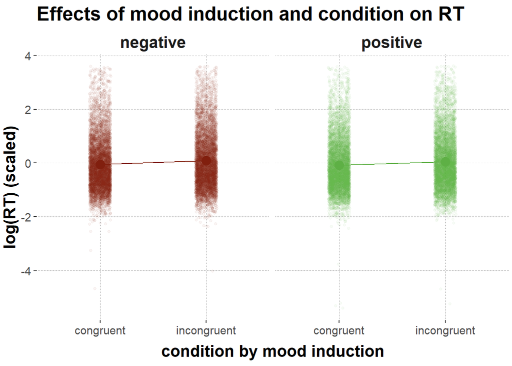

The plot does not show much difference between groups. What happens if we zoom in?

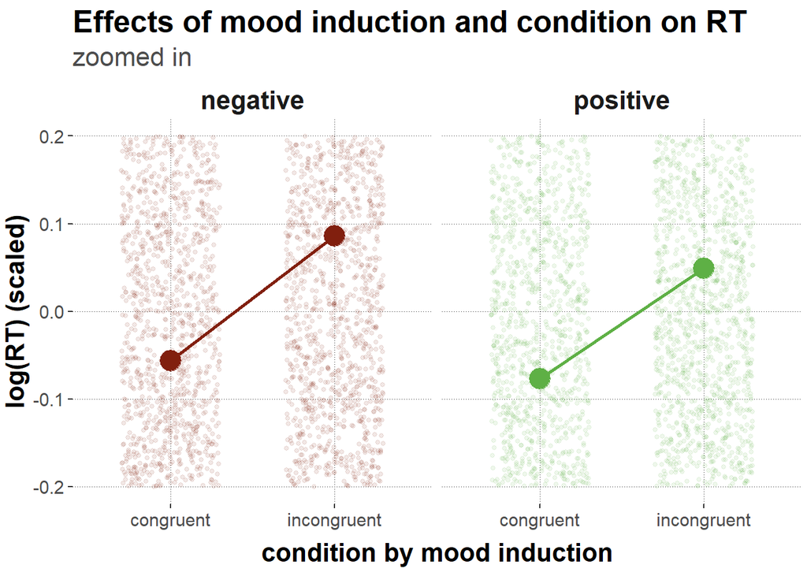

combined in one plot:

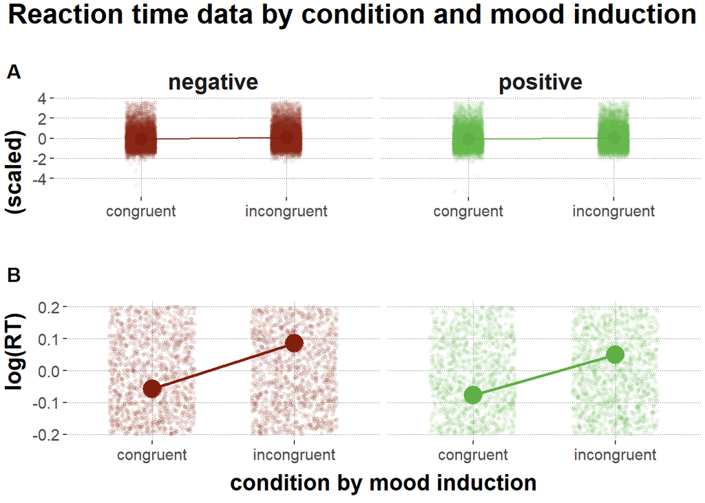

Visual inspection reveals a small difference between congruent and incongruent conditions, but not between positive and negative mood induction. Reaction times in the incongruent condition seem to be longer than reaction times in the congruent condition for both positive and negative mood induction conditions (although the scale is really, really small and the effect seems to be really small as well).

### Statistical model as preregistered

The model predicts log-transformed and scaled reaction times (continuous) in terms of mood induction (discrete), condition (discrete) and their interaction. The relation RT ~ mood_induction * condition is hierarchical and modeled with group-level varying intercepts and slopes for ‘subject_id’.

Fitting a linear model with a gaussian distribution.

```
##   subject_id trial condition mood_induction  log_RT_s pictures stimulus_valence
## 1          1     5 congruent       positive 1.4462897       72         negative
## 2          1     6 congruent       positive 0.6362078       62         negative
## 3          1     7 congruent       positive 2.3794958       46         negative
## 4          1     8 congruent       positive 0.6346828       84         negative
## 5          1     9 congruent       positive 1.0062967       17         positive
## 6          1    10 congruent       positive 2.0084809       30         positive
##   response
## 1     push
## 2     push
## 3     push
## 4     push
## 5     pull
## 6     pull
```

I chose a weakly informative priors for the model-specific parameter “sigma”, and the group-level effects: student_t distribution with 3 degrees of freedom, centered on 0, ranging between -10 and 10 with most values being close to zero. I decided for a slightly more constraining prior on the intercept: a student_t distribution with 5 degrees of freedom, centered on -0.2 ranging from -5 to 5. And an agnostic prior for the population-level effects: normal distribution centered on 0 with wide standard deviation of 10.

```
##  Family: gaussian
##   Links: mu = identity; sigma = identity
## Formula: log_RT_s ~ condition * mood_induction + (condition * mood_induction || subject_id)
##    Data: df_aat_log1 (Number of observations: 28846)
##   Draws: 4 chains, each with iter = 10000; warmup = 5000; thin = 1;
##          total post-warmup draws = 20000
##
## Priors:
## b ~ normal(0, 10)
## Intercept ~ student_t(5, -0.2, 1)
## sd ~ student_t(3, 0, 2)
## sigma ~ student_t(3, 0, 2)
##
## Group-Level Effects:
## ~subject_id (Number of levels: 95)
##                                                 Estimate Est.Error l-95% CI
## sd(Intercept)                                       0.66      0.05     0.56
## sd(conditionincongruent)                            0.28      0.02     0.23
## sd(mood_inductionpositive)                          0.46      0.04     0.40
## sd(conditionincongruent:mood_inductionpositive)     0.26      0.03     0.21
##                                                 u-95% CI Rhat Bulk_ESS Tail_ESS
## sd(Intercept)                                       0.76 1.00     1914     2873
## sd(conditionincongruent)                            0.33 1.00     6715    10626
## sd(mood_inductionpositive)                          0.54 1.00     3872     6497
## sd(conditionincongruent:mood_inductionpositive)     0.32 1.00     7949    12788
##
## Population-Level Effects:
##                                             Estimate Est.Error l-95% CI
## Intercept                                      -0.04      0.07    -0.17
## conditionincongruent                            0.15      0.03     0.09
## mood_inductionpositive                         -0.02      0.05    -0.12
## conditionincongruent:mood_inductionpositive    -0.02      0.03    -0.09
##                                             u-95% CI Rhat Bulk_ESS Tail_ESS
## Intercept                                       0.10 1.00     1041     2236
## conditionincongruent                            0.21 1.00     4583     7873
## mood_inductionpositive                          0.07 1.00     1990     4516
## conditionincongruent:mood_inductionpositive     0.04 1.00     8643    12046
##
## Family Specific Parameters:
##       Estimate Est.Error l-95% CI u-95% CI Rhat Bulk_ESS Tail_ESS
## sigma     0.75      0.00     0.74     0.76 1.00    31451    14203
##
## Draws were sampled using sampling(NUTS). For each parameter, Bulk_ESS
## and Tail_ESS are effective sample size measures, and Rhat is the potential
## scale reduction factor on split chains (at convergence, Rhat = 1).
```

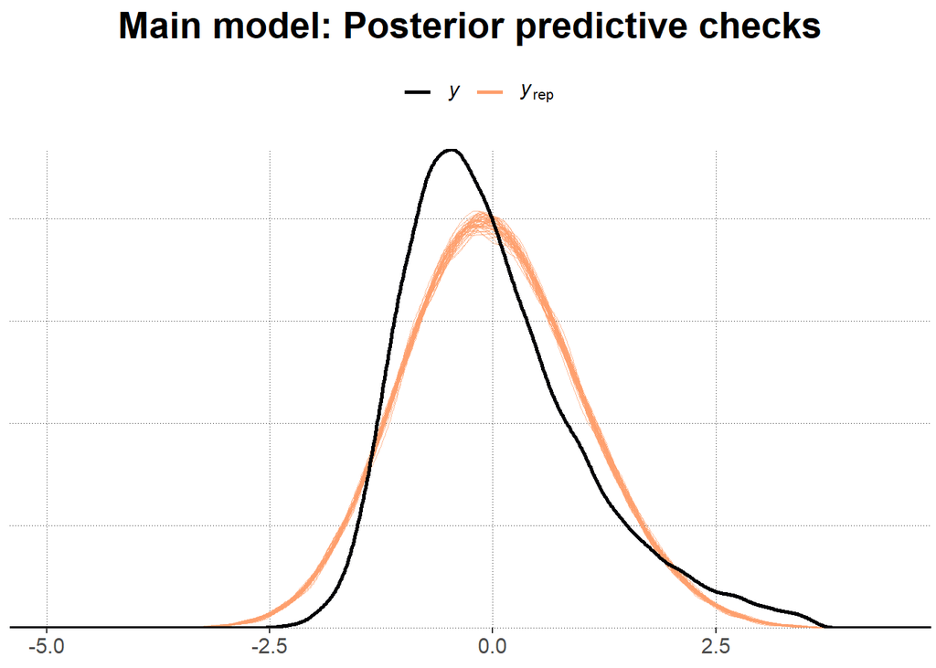

The model fit is okay, but it’s also very obvious that the normal link function failed to capture the skewed distribution of the data. But due to previous studies that successfully used a linear model with normal link function, the fit is considered good enough.

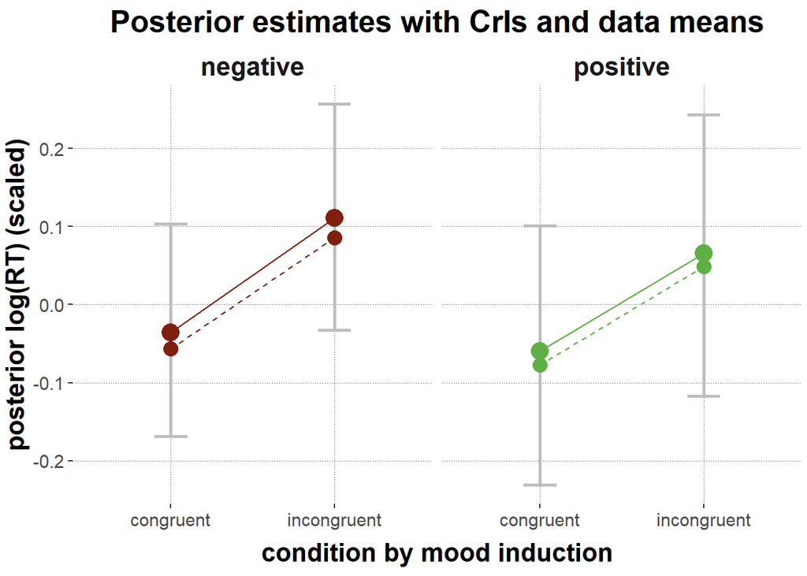

Posterior estimates match the data very well. The posterior means are nearly the same as the means from the data distribution (compare to figure above).

#### Difference distributions for the difference in reaction times between congruent and incongruent condition:

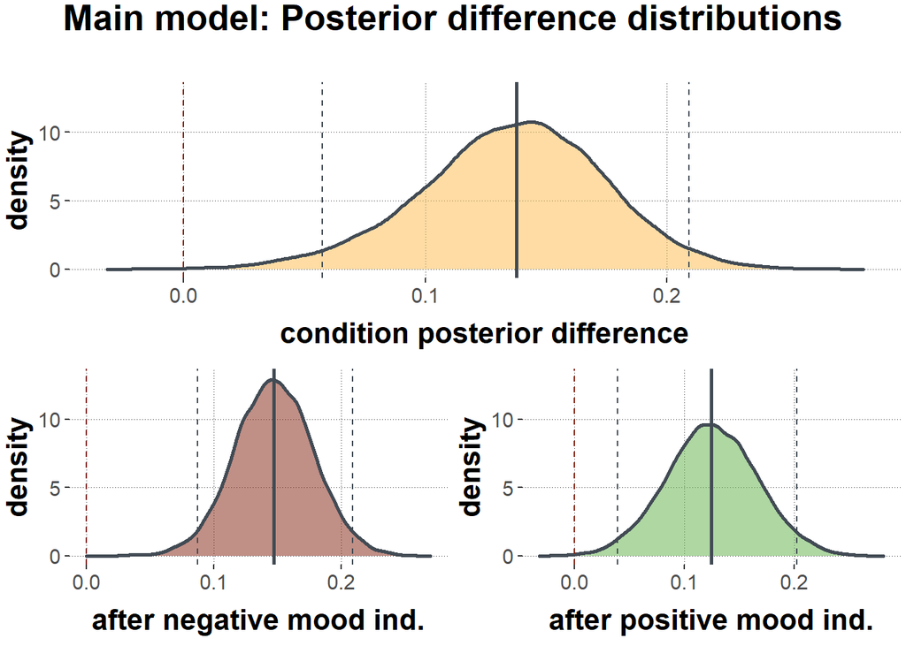

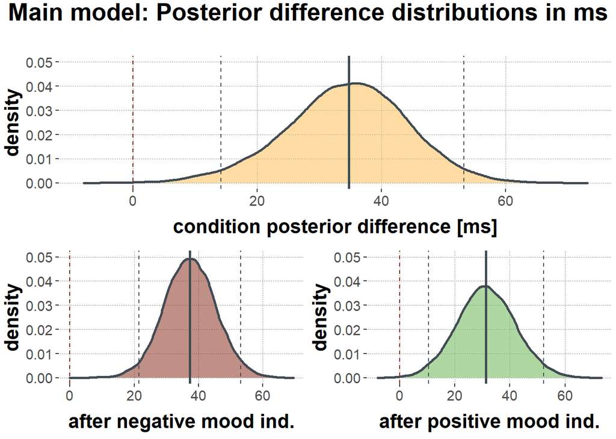

```
## # A tibble: 3 x 4
##   posteriors                               median CrI_lower CrI_upper
##   <chr>                                     <dbl>     <dbl>     <dbl>
## 1 condition difference                       34.7      14.1      53.3
## 2 difference after negative mood induction   37.3      21.4      53.1
## 3 difference after positive mood induction   31.3      10.5      52.2
```

```
## [1] "condition difference regardless of mood induction:"
```

```
## Summary of Posterior Distribution
##
## Parameter | Median |       95% CI |     pd |          ROPE | % in ROPE
## ----------------------------------------------------------------------
## posterior |   0.14 | [0.06, 0.21] | 99.94% | [-0.10, 0.10] |    14.72%
```

```
## [1] "condition difference after negative mood induction:"
```

```
## Summary of Posterior Distribution
##
## Parameter | Median |       95% CI |   pd |          ROPE | % in ROPE
## --------------------------------------------------------------------
## posterior |   0.15 | [0.09, 0.21] | 100% | [-0.10, 0.10] |     3.81%
```

```
## [1] "condition difference after positive mood induction:"
```

```
## Summary of Posterior Distribution
##
## Parameter | Median |       95% CI |     pd |          ROPE | % in ROPE
## ----------------------------------------------------------------------
## posterior |   0.12 | [0.04, 0.20] | 99.89% | [-0.10, 0.10] |    26.66%
```

```
## [1] "Is there a difference between the AAB (i.e. difference in RTs between conditions) after positive compared to after negative MI?"
```

```
## [1] "positive AAB in negative AAB:"
```

```
## Summary of Posterior Distribution
##
## Parameter |       95% CI |         ROPE | % in ROPE
## ---------------------------------------------------
## posterior | [0.04, 0.20] | [0.09, 0.21] |    83.27%
```

```
## [1] "negative AAB in positive AAB:"
```

```
## Summary of Posterior Distribution
##
## Parameter |       95% CI |         ROPE | % in ROPE
## ---------------------------------------------------
## posterior | [0.09, 0.21] | [0.04, 0.20] |    98.46%
```

#### Difference distributions for the difference in reaction times between positive and negative mood induction:

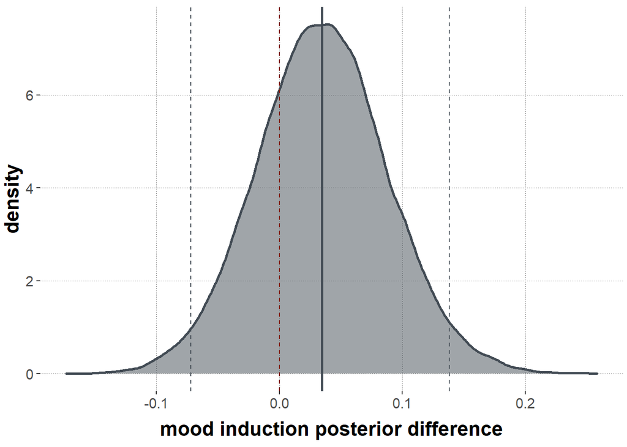

```
## [1] "mood induction difference regardless of condition:"
```

```
## Summary of Posterior Distribution
##
## Parameter | Median |        95% CI |     pd |          ROPE | % in ROPE
## -----------------------------------------------------------------------
## posterior |   0.03 | [-0.07, 0.14] | 74.70% | [-0.10, 0.10] |    91.43%
```

The hypothesis tests according to the hypotheses above support the results:

```r
# Hypothesis 1: After negative mood induction, reaction times are shorter in the incongruent than in the congruent condition.
hypothesis(fit_MImodel, "conditionincongruent < 0")
```

```
## Hypothesis Tests for class b:
##                 Hypothesis Estimate Est.Error CI.Lower CI.Upper Evid.Ratio
## 1 (conditionincongr... < 0     0.15      0.03      0.1      0.2          0
##   Post.Prob Star
## 1         0
## ---
## 'CI': 90%-CI for one-sided and 95%-CI for two-sided hypotheses.
## '*': For one-sided hypotheses, the posterior probability exceeds 95%;
## for two-sided hypotheses, the value tested against lies outside the 95%-CI.
## Posterior probabilities of point hypotheses assume equal prior probabilities.
```

```r
# --> reject hypothesis, test other way:
hypothesis(fit_MImodel, "conditionincongruent > 0")
```

```
## Hypothesis Tests for class b:
##                 Hypothesis Estimate Est.Error CI.Lower CI.Upper Evid.Ratio
## 1 (conditionincongr... > 0     0.15      0.03      0.1      0.2        Inf
##   Post.Prob Star
## 1         1    *
## ---
## 'CI': 90%-CI for one-sided and 95%-CI for two-sided hypotheses.
## '*': For one-sided hypotheses, the posterior probability exceeds 95%;
## for two-sided hypotheses, the value tested against lies outside the 95%-CI.
## Posterior probabilities of point hypotheses assume equal prior probabilities.
```

```r
# Hypothesis 2: After positive mood induction, reaction times are longer in the incongruent than in the congruent condition.
hypothesis(fit_MImodel, "conditionincongruent + `conditionincongruent:mood_inductionpositive` > 0")
```

```
## Hypothesis Tests for class b:
##                 Hypothesis Estimate Est.Error CI.Lower CI.Upper Evid.Ratio
## 1 (conditionincongr... > 0     0.12      0.04     0.06     0.19     868.57
##   Post.Prob Star
## 1         1    *
## ---
## 'CI': 90%-CI for one-sided and 95%-CI for two-sided hypotheses.
## '*': For one-sided hypotheses, the posterior probability exceeds 95%;
## for two-sided hypotheses, the value tested against lies outside the 95%-CI.
## Posterior probabilities of point hypotheses assume equal prior probabilities.
```

```r
# are reaction times different from each other in the different mood induction conditions?

# Is congruent negative different from congruent positive?
hypothesis(fit_MImodel, "mood_inductionpositive < 0")
```

```
## Hypothesis Tests for class b:
##                 Hypothesis Estimate Est.Error CI.Lower CI.Upper Evid.Ratio
## 1 (mood_inductionpo... < 0    -0.02      0.05     -0.1     0.06       2.25
##   Post.Prob Star
## 1      0.69
## ---
## 'CI': 90%-CI for one-sided and 95%-CI for two-sided hypotheses.
## '*': For one-sided hypotheses, the posterior probability exceeds 95%;
## for two-sided hypotheses, the value tested against lies outside the 95%-CI.
## Posterior probabilities of point hypotheses assume equal prior probabilities.
```

```r
# Is incongruent negative different from incongruent positive?
hypothesis(fit_MImodel, "mood_inductionpositive + `conditionincongruent:mood_inductionpositive` < 0")
```

```
## Hypothesis Tests for class b:
##                 Hypothesis Estimate Est.Error CI.Lower CI.Upper Evid.Ratio
## 1 (mood_inductionpo... < 0    -0.05      0.06    -0.14     0.05       4.05
##   Post.Prob Star
## 1       0.8
## ---
## 'CI': 90%-CI for one-sided and 95%-CI for two-sided hypotheses.
## '*': For one-sided hypotheses, the posterior probability exceeds 95%;
## for two-sided hypotheses, the value tested against lies outside the 95%-CI.
## Posterior probabilities of point hypotheses assume equal prior probabilities.
```

```r
# ---> not really. there is some evidence (80%) for a difference between mood inductions for incongruent conditions, but it is not substantial
```